# Project 2: Data Mining, Classification, Prediction

SDS322E

# Mining, Classification, Prediction

## Kaelen Saythongkham kps827

### Introduction

```r
library(tidyverse)

og_data <- read_csv("./CollegeDistance.csv")
og_data <- og_data %>%
    na.omit()

# female = 1 and male = 0
data_adj <- og_data %>%
    mutate(gender = ifelse(gender == "female", 1, 0))

# rename the first column
names(data_adj)[1] <- "Student"
```

### Cluster Analysis

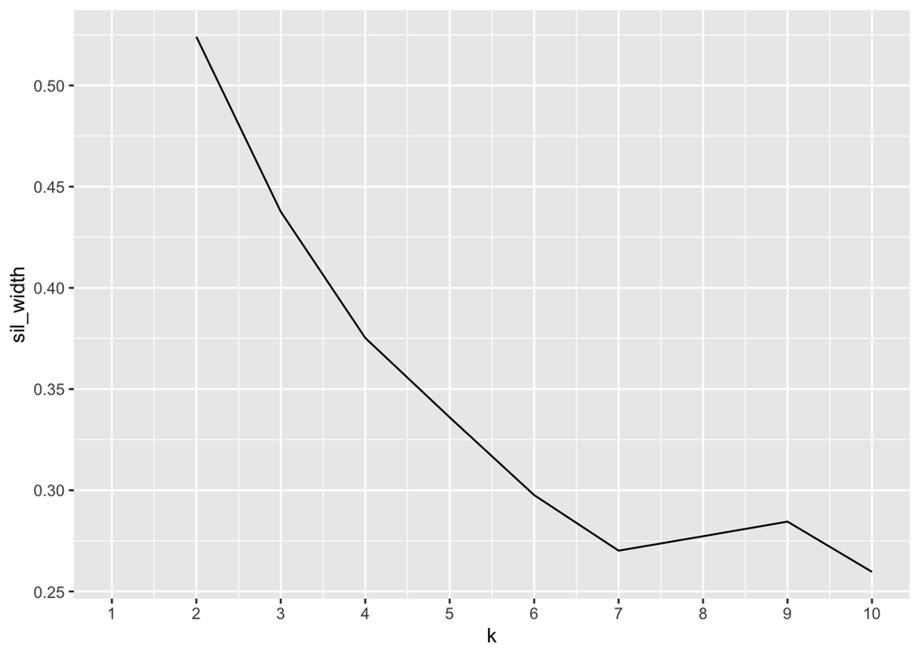

```r
library(cluster)
library(GGally)

data_select <- data_adj %>%
    select(score, distance, tuition, education)

sil_width <- vector()
for (i in 2:10) {
    pam_fit <- pam(data_select, k = i)
    sil_width[i] <- pam_fit$silinfo$avg.width
}
ggplot() + geom_line(aes(x = 1:10, y = sil_width)) + scale_x_continuous(name = "k",
    breaks = 1:10)
```

```r
# it seems like k = 2 would be the best number of clusters

# 2. running the PAM clustering algo on raw data for 2
# clusters
data_pam <- data_select %>%
    pam(2)
data_pam
```

```
## Medoids:
##        ID score distance tuition education
## [1,] 2708 42.89      1.5 0.89376        13
## [2,] 2660 57.74      1.5 0.89376        14
## Clustering vector:
##   [1] 1 1 1 1 1 2 2 2 2 2 1 2 2 2 2 2 2 1 2 2 2 2 2 2 2 1 1 2 2 2 2 1 2 2 2 1 1
##  [38] 2 2 2 2 2 1 2 1 2 1 2 1 2 1 1 1 1 2 1 2 1 2 1 2 2 2 2 2 2 2 1 2 2 2 1 1 2
##  [75] 2 2 2 2 2 2 2 2 2 2 1 1 2 2 1 1 1 2 2 1 1 1 2 2 2 1
##  [ reached getOption("max.print") -- omitted 4639 entries ]
## Objective function:
##    build     swap
## 5.828797 4.894101
##
## Available components:
##  [1] "medoids"    "id.med"     "clustering" "objective"  "isolation"
##  [6] "clusinfo"   "silinfo"    "diss"       "call"       "data"
```

[figure not shown]

```r
plot(data_pam, which = 2)
```

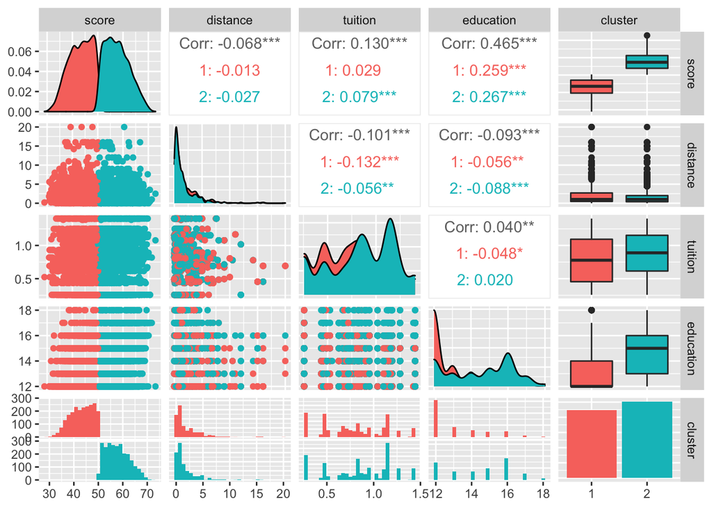

```r
data_select %>%
    mutate(cluster = factor(data_pam$clustering)) %>%
    ggpairs(cols = 1:4, aes(color = cluster))
```

In terms of overall average silhouette width, the cluster is not very weak, but it is not strong either. It seems that student 2708 and student 2660 are the medoids or the representatives of their respective clusters. They seem the most similar on distance and tuition, but vary on their scores and education levels.

The two clusters seem similar in size and silhouette width, which makes sense as the tuition and distance variables are not unique to one student.I believe the cluster solution could be better, but with the current data, the solution fits as well as we can hope for the data.

I would like to highlight that it seems that the clusters were separated by score, as we can see by the various pairwise combinations of the variables. It is interesting, but it makes sense as scores seem to be the only variable which the student has the ability to control, compared to their education level, average tuition in their state, and their distance from a 4-year college. I thought it was an interesting outcome.

### Dimensionality Reduction with PCA

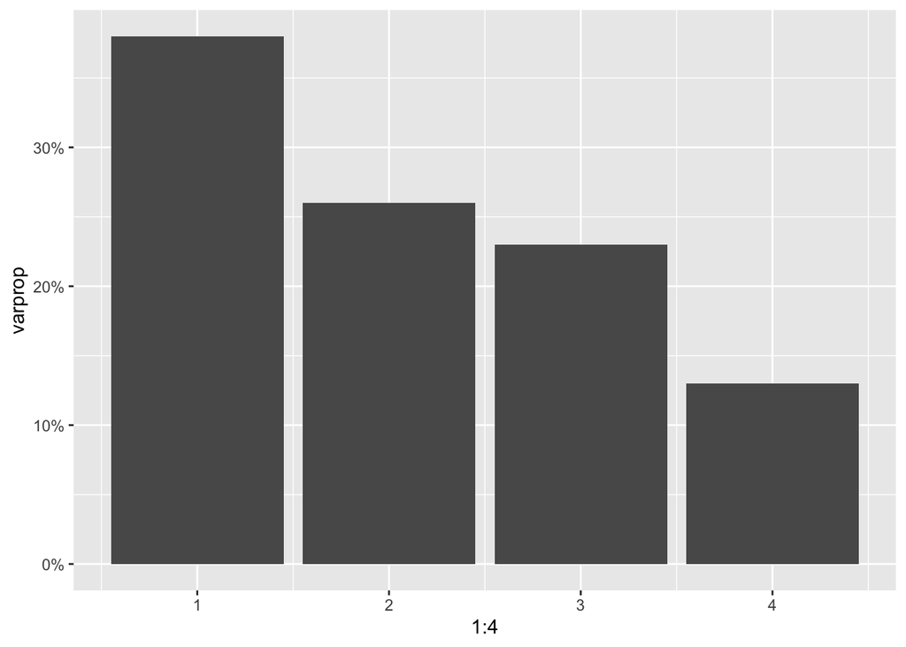

```r
data_select <- data_adj %>%
    select(score, distance, tuition, education)

princomp(data_select, cor = T) -> pca1
eigval <- pca1$sdev^2
varprop = round(eigval/sum(eigval), 2)

ggplot() + geom_bar(aes(y = varprop, x = 1:4), stat = "identity") +
    geom_text(aes(label = ..count..), stat = "count", color = "white") +
    scale_y_continuous(labels = scales::percent)
```

```r
summary(pca1, loadings = T)
```

```
## Importance of components:
##                           Comp.1    Comp.2    Comp.3    Comp.4
## Standard deviation     1.2365994 1.0193230 0.9528036 0.7238562
## Proportion of Variance 0.3822945 0.2597548 0.2269587 0.1309919
## Cumulative Proportion  0.3822945 0.6420494 0.8690081 1.0000000
##
## Loadings:
##           Comp.1 Comp.2 Comp.3 Comp.4
## score      0.668  0.212  0.107  0.705
## distance  -0.250  0.647  0.717
## tuition    0.260 -0.668  0.681 -0.149
## education  0.651  0.299 -0.106 -0.690
```

PC1 captures the trade-off between score, tuition, and education to distance, PC2 highlights the trade-off between score, distance, and education to tuition, PC3 highlights the trade-off between score, distance, and tuition to education, while PC4 emphasizes the trade-off between score to tuition and education.

Scoring high on PC1 means you have a higher score, a higher tuition rate, and higher education level, but scoring low means you have a farther distance from a 4-year college and lower rates on other categories. Scoring high on PC2 means you have a higher score, a farther distance from a 4-year college, and a higher education level, while scoring low means you have a higher tuition rate and lower rates on other categories. Scoring high on PC3 means you have a higher score, a farther distance, and a higher tuition rate, while scoring low means you have a higher education level and lower rates on other categories. Scoring high on PC4 means you have a higher score, while scoring low means you have a higher tuition rate and a higher education level and lower scores.

In this case, we would only want to keep PC1, PC2, and PC3, which we can see explains 86.90081% of the total variance in the college dataset.

### Linear Classifier

```r
logistic_fit <- glm(gender == "female" ~ score + distance + tuition,
    data = og_data, family = "binomial")

prob_reg <- predict(logistic_fit, type = "response")
class_diag(prob_reg, truth = og_data$gender, positive = "female")
```

```
##            acc   sens   spec    ppv     f1     ba    auc
## Metrics 0.5624 0.8985 0.1538 0.5634 0.6926 0.5261 0.5469
```

```r
set.seed(1234)
k = 10

data <- sample_frac(og_data)  #randomly order rows
folds <- rep(1:k, length.out = nrow(data))  #create folds

diags <- NULL
for (i in 1:k) {
    # create training and test sets
    train <- data[folds != i, ]
    test <- data[folds == i, ]
    truth <- test$gender

    # train model
    fit <- glm(gender == "female" ~ score + distance + tuition,
        data = train, family = "binomial")

    # test model
    probs <- predict(fit, newdata = test, type = "response")

    # get performance metrics for each fold
    diags <- rbind(diags, class_diag(probs, truth, positive = "female"))
}

# average performance metrics across all folds
summarize_all(diags, mean)
```

```
##       acc    sens    spec     ppv      f1      ba     auc
## 1 0.55687 0.89602 0.14523 0.56023 0.68899 0.52065 0.54397
```

### Non-Parametric Classifier

```r
library(caret)

knn_fit <- knn3(gender == "female" ~ score + distance + tuition,
    data = og_data)

prob_knn <- predict(knn_fit, og_data)[, 2]
class_diag(prob_knn, truth = og_data$gender, positive = "female")
```

```
##            acc   sens  spec    ppv     f1     ba    auc
## Metrics 0.6976 0.7623 0.619 0.7086 0.7345 0.6906 0.7565
```

```r
set.seed(1234)
k = 10

data <- sample_frac(og_data)  #randomly order rows
folds <- rep(1:k, length.out = nrow(data))  #create folds

diags <- NULL
for (i in 1:k) {
    # create training and test sets
    train <- data[folds != i, ]
    test <- data[folds == i, ]
    truth <- test$gender

    # train model
    fit <- knn3(gender == "female" ~ score + distance + tuition,
        data = train)

    # test model
    probs <- predict(fit, newdata = test)[, 2]

    # get performance metrics for each fold
    diags <- rbind(diags, class_diag(probs, truth, positive = "female"))
}

# average performance metrics across all folds
summarize_all(diags, mean)
```

```
##       acc    sens    spec     ppv      f1      ba     auc
## 1 0.51445 0.59233 0.41953 0.55365 0.57217 0.50594 0.50915
```

### Regression/Numeric Prediction

```r
# predict scores using distance and tuition
fit <- lm(score ~ distance + tuition + education, data = og_data)
yhat <- predict(fit)

mse <- mean((og_data$score - yhat)^2)
mse
```

```
## [1] 58.36751
```

```r
set.seed(1234)
k = 10

data <- sample_frac(og_data)  #randomly order rows
folds <- rep(1:k, length.out = nrow(data))  #create folds

diags <- NULL
for (i in 1:k) {
    train <- data[folds != i, ]
    test <- data[folds == i, ]

    # fit linear regression model to training set
    fit <- lm(score ~ distance + tuition + education, data = train)

    # get predictions/yhats on test set
    yhat <- predict(fit, newdata = test)

    # compute prediction error (MSE)
    diags <- mean((test$score - yhat)^2)
}

# average MSE across all folds
mean(diags)
```

```
## [1] 56.21403
```

### Python

```r
library(reticulate)
# py_install('pandas') py_install('scikit-learn')
# py_install(packages = 'matplotlib')
use_python("/usr/bin/python3", required = F)
```

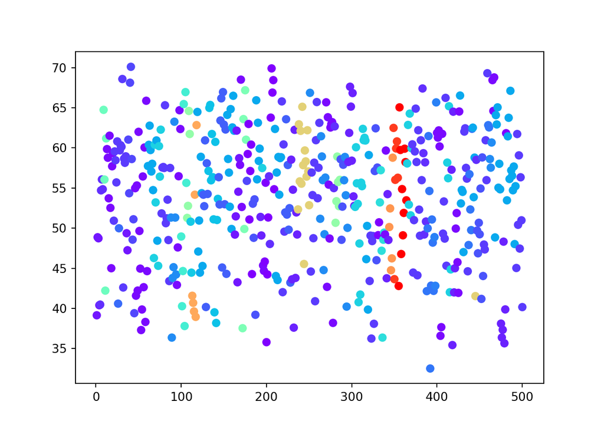

```python
import matplotlib.pyplot as plt

college_data = r.data_adj
college_data = college_data.filter(["Student", "gender", "score", "distance"])
college_data = college_data.iloc[:500, :]

plt.scatter(college_data["Student"], college_data["score"], c=college_data["distance"], cmap="rainbow")
plt.show()
```

In this python script, I plot the first 500 students scores and colour by their disatnces from a 4-year college. I thought it would be interesting to see what matplot would provide in terms of graphs and some of the patterns found in the plot were actually pretty neat!

### Concluding Remarks

Overall, this analysis was pretty interesting. I initially chose this dataset because it had some interesting variables that were not unique to any student and I wanted to see how that would affect the data. It was interesting seeing the model attempt to predict the gender of a student solely based on their locations (as distance and tuition were based on location) and their score on an achievement test and I would say that I was surprised on some of the outcomes.

Although I did not have any hard hitting conclusions or as many pretty graphs as I did in the last project, I have definitely learned a lot about analysis with this project and see the value of each of these analyses!